# Ejercicio de limpieza de datos

Guillermo

2024-04-09

### PASO 0

IMPORTANTE: LEER EL DOCUMENTO README.

INSTALACION DE LIBRERIAS NECESARIAS

```r
library(readxl)
library(dplyr)
```

### PASO 1

CARGA DE LOS ARCHIVOS Y VISUALIZACION INICIAL VEASE LAS NOTAS ADICIONALES A CADA LADO DEL CODIGO.  
CONOCEMOS LA TERMINACION DEL ARCHIVO EXCEL.  
SI NO, USARIAMOS read_excel.

```r
Poblacion01<- read_xls("C:/Datos/padronmunicipal/pobmun01.xls")
Poblacion21<- read_xlsx("C:/Datos/padronmunicipal/pobmun21.xlsx")
```

NORMALMENTE SE USARIA VIEW, O HEAD Y TAIL, NO LAS 3.  
PONDREMOS LAS 3 A EFECTOS DIDACTICOS.

```r
View (Poblacion01)
View (Poblacion21)


head (Poblacion01)
```

```
## # A tibble: 6 × 7
##   Cifras de población resultantes de la Re…¹ ...2  ...3  ...4  ...5  ...6  ...7
##   <chr>                                      <chr> <chr> <chr> <chr> <chr> <chr>
## 1 CPRO                                       PROV… CMUN  NOMB… POB01 VARO… MUJE…
## 2 01                                         Álava 001   Aleg… 1486  763   723
## 3 01                                         Álava 002   Amur… 9695  4826  4869
## 4 01                                         Álava 049   Añana 190   102   88
## 5 01                                         Álava 003   Aram… 1447  760   687
## 6 01                                         Álava 006   Armi… 158   82    76
## # ℹ abbreviated name:
## #   ¹`Cifras de población resultantes de la Revisión del Padrón municipal a 1 de enero de 2001`
```

```r
head (Poblacion21)
```

```
## # A tibble: 6 × 7
##   Cifras de población resultantes de la Re…¹ ...2  ...3  ...4  ...5  ...6  ...7
##   <chr>                                      <chr> <chr> <chr> <chr> <chr> <chr>
## 1 CPRO                                       PROV… CMUN  NOMB… POB21 HOMB… MUJE…
## 2 02                                         Alba… 001   Aben… 748   365   383
## 3 02                                         Alba… 002   Alat… 496   272   224
## 4 02                                         Alba… 003   Alba… 1727… 84365 88357
## 5 02                                         Alba… 004   Alba… 681   354   327
## 6 02                                         Alba… 005   Albo… 670   350   320
## # ℹ abbreviated name:
## #   ¹`Cifras de población resultantes de la Revisión del Padrón municipal a 1 de enero de 2021`
```

```r
tail(Poblacion01)
```

```
## # A tibble: 6 × 7
##   Cifras de población resultantes de la Re…¹ ...2  ...3  ...4  ...5  ...6  ...7
##   <chr>                                      <chr> <chr> <chr> <chr> <chr> <chr>
## 1 50                                         Zara… 295   Vist… 36    19    17
## 2 50                                         Zara… 296   Zaid… 588   293   295
## 3 50                                         Zara… 297   Zara… 6109… 2944… 3165…
## 4 50                                         Zara… 298   Zuera 5562  2853  2709
## 5 51                                         Ceuta 001   Ceuta 75694 38884 36810
## 6 52                                         Meli… 001   Meli… 68789 35027 33762
## # ℹ abbreviated name:
## #   ¹`Cifras de población resultantes de la Revisión del Padrón municipal a 1 de enero de 2001`
```

```r
tail(Poblacion21)
```

```
## # A tibble: 6 × 7
##   Cifras de población resultantes de la Re…¹ ...2  ...3  ...4  ...5  ...6  ...7
##   <chr>                                      <chr> <chr> <chr> <chr> <chr> <chr>
## 1 50                                         Zara… 294   Vill… 89    48    41
## 2 50                                         Zara… 282   Vilu… 71    36    35
## 3 50                                         Zara… 295   Vist… 51    29    22
## 4 50                                         Zara… 296   Zaid… 432   221   211
## 5 50                                         Zara… 297   Zara… 6753… 3231… 3521…
## 6 50                                         Zara… 298   Zuera 8591  4427  4164
## # ℹ abbreviated name:
## #   ¹`Cifras de población resultantes de la Revisión del Padrón municipal a 1 de enero de 2021`
```

CORREGIMOS EL PROBLEMA DEBIDO A QUE LA PRIMERA LINEA DEL EXCEL ES UNA NOTA.

```r
Poblacion01<- read_xls("C:/Datos/padronmunicipal/pobmun01.xls", skip = 1, col_names = TRUE)
Poblacion21<- read_xlsx("C:/Datos/padronmunicipal/pobmun21.xlsx", skip = 1, col_names =  TRUE)
```

### PASO 2

ANALISIS (muy) INICIAL DE LOS DATOS; CENTRANDONOS EN LA CANTIDAD DE POBLACION NUEVAMENTE, VEASE NOTAS INTERIORES AL LADO DEL CODIGO.

ANALISIS SIMPLES MUY INICIALES. SOLO PARA TENER UNA IDEA. SON PARA NOSOTROS Y NO PARA LOS DEMAS.  
POR ELLO NO NOS MOLESTAMOS EN COSAS COMO CAMBIAR NOMBRES EN EL GRAFICO ETC.

```r
dim (Poblacion01)
```

```
## [1] 8107    7
```

```r
dim (Poblacion21)             ###   ###
```

```
## [1] 8131    7
```

```r
summary (Poblacion01)
```

```
##      CPRO            PROVINCIA             CMUN              NOMBRE
##  Length:8107        Length:8107        Length:8107        Length:8107
##  Class :character   Class :character   Class :character   Class :character
##  Mode  :character   Mode  :character   Mode  :character   Mode  :character
##
##
##
##      POB01            VARONES           MUJERES
##  Min.   :      5   Min.   :      4   Min.   :      1
##  1st Qu.:    191   1st Qu.:    100   1st Qu.:     90
##  Median :    571   Median :    294   Median :    279
##  Mean   :   5072   Mean   :   2487   Mean   :   2584
##  3rd Qu.:   2184   3rd Qu.:   1104   3rd Qu.:   1082
##  Max.   :2957058   Max.   :1380788   Max.   :1576270
```

```r
summary (Poblacion21)
```

```
##      CPRO            PROVINCIA             CMUN              NOMBRE
##  Length:8131        Length:8131        Length:8131        Length:8131
##  Class :character   Class :character   Class :character   Class :character
##  Mode  :character   Mode  :character   Mode  :character   Mode  :character
##
##
##
##      POB21            HOMBRES           MUJERES
##  Min.   :      3   Min.   :      3   Min.   :      0
##  1st Qu.:    153   1st Qu.:     84   1st Qu.:     69
##  Median :    523   Median :    276   Median :    248
##  Mean   :   5828   Mean   :   2856   Mean   :   2972
##  3rd Qu.:   2416   3rd Qu.:   1218   3rd Qu.:   1191
##  Max.   :3305408   Max.   :1540894   Max.   :1764514
```

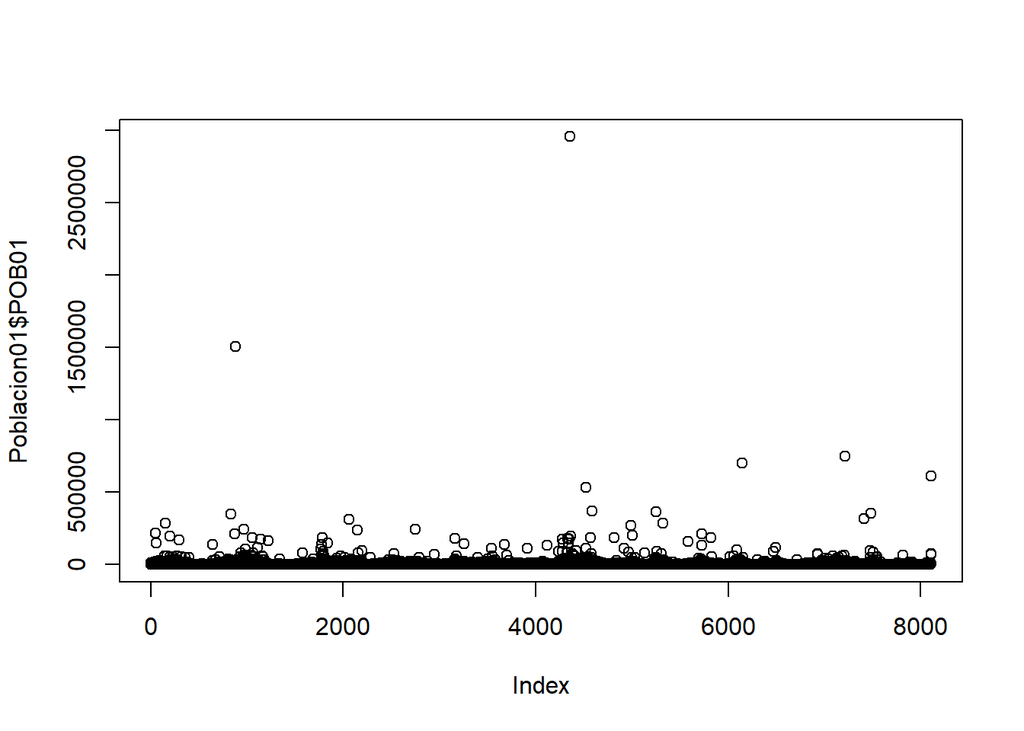

```r
plot (Poblacion01$POB01)
```

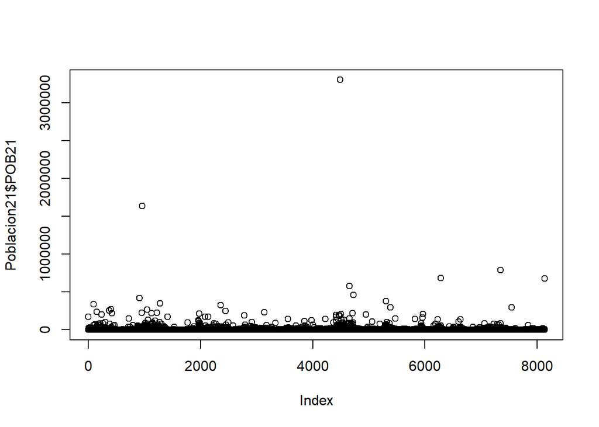

```r
plot (Poblacion21$POB21)
```

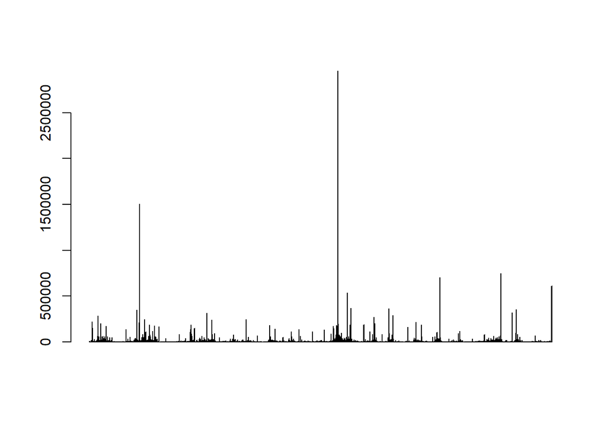

```r
barplot (Poblacion01$POB01)
```

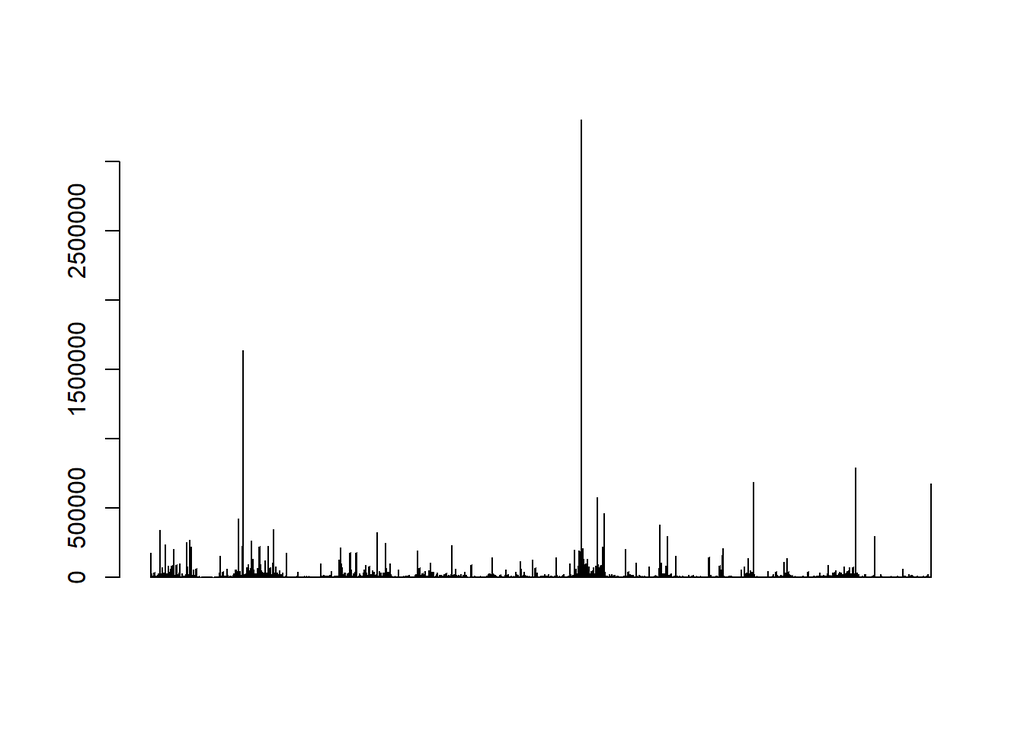

```r
barplot (Poblacion21$POB21)
```

### PASO 3

ESTUDIO DE LAS DIFERENCIAS EN EL LISTADO DE MUNICIPIOS.

EL PUNTO ANTERIOR NOS MOSTRO QUE EL NUMERO DE FILAS (MUNICIPIOS) ES DIFERENTE.  
DEBE ESTUDIARSE Y SOLUCIONARSE AL COMBINAR LOS DATOS DE LAS TABLAS.

```r
Discordanciasmunicip <- anti_join (Poblacion01, Poblacion21, by= c("NOMBRE","PROVINCIA"))
print (Discordanciasmunicip)
```

```
## # A tibble: 1,340 × 7
##    CPRO  PROVINCIA CMUN  NOMBRE             POB01 VARONES MUJERES
##    <chr> <chr>     <chr> <chr>              <dbl>   <dbl>   <dbl>
##  1 01    Álava     001   Alegría-Dulantzi    1486     763     723
##  2 01    Álava     002   Amurrio             9695    4826    4869
##  3 01    Álava     049   Añana                190     102      88
##  4 01    Álava     003   Aramaio             1447     760     687
##  5 01    Álava     006   Armiñón              158      82      76
##  6 01    Álava     037   Arraia-Maeztu        715     387     328
##  7 01    Álava     008   Arrazua-Ubarrundia   743     394     349
##  8 01    Álava     004   Artziniega          1331     661     670
##  9 01    Álava     009   Asparrena           1585     793     792
## 10 01    Álava     010   Ayala/Aiara         2086    1033    1053
## # ℹ 1,330 more rows
```

VEMOS QUE HAY MAS DE 1300 DIFERENCIAS.  
LAS ESTUDIAREMOS MAS DETALLADAMENTE.

```r
municipios01 <-Poblacion01[,c("NOMBRE", "PROVINCIA")]
municipios21 <-Poblacion21[,c("NOMBRE", "PROVINCIA")]
diferencias <- setdiff (municipios01,municipios21)
print(diferencias)
```

```
## # A tibble: 1,340 × 2
##    NOMBRE             PROVINCIA
##    <chr>              <chr>
##  1 Alegría-Dulantzi   Álava
##  2 Amurrio            Álava
##  3 Añana              Álava
##  4 Aramaio            Álava
##  5 Armiñón            Álava
##  6 Arraia-Maeztu      Álava
##  7 Arrazua-Ubarrundia Álava
##  8 Artziniega         Álava
##  9 Asparrena          Álava
## 10 Ayala/Aiara        Álava
## # ℹ 1,330 more rows
```

### PASO 4

EN EL PUNTO ANTERIOR, HEMOS AMPLIANDO EL NUMERO DE ERRORES VISIBLES USANDO print(diferencias, n=1400).  
NO LO HEMOS INCLUIDO PARA NO SATURAR EL DOCUMENTO.

VEMOS EN ESA AMPLIACION QUE MUCHOS DE LOS ERRORES SON POR DISTINTA NOMENCLATURA DE LA PROVINCIA.  
INTENTAREMOS CORREGIR LAS DIFERENCIAS POR ESA UNA DIFERENTE NOMENCLATURA.

SOBREESCRIBIMOS LA VARIABLE DIFERENCIA ANTERIOR. NO VAMOS A NECESITARLA. EN OTROS CASOS PUEDE SER ADECUADO CONSERVARLA.

```r
Provincias01 <- unique(Poblacion01$PROVINCIA)
Provincias21 <- unique(Poblacion21$PROVINCIA)



diferencias <- setdiff (Provincias01, Provincias21)
print (diferencias)
```

```
## [1] "Álava"           "Balears (Illes)" "Coruña (A)"      "Guipúzcoa"
## [5] "Rioja (La)"      "Palmas (Las)"    "Vizcaya"
```

ESTO NOS HA DADO LOS NOMBRES DISTINTOS DE LA TABLA POBLACION 01.  
PARA OBTENER LOS DE POBLACION 21, LO MAS FACIL ES INVERTIR EL ORDEN EN setdiff.

```r
diferencias2 <- setdiff (Provincias21, Provincias01)
print (diferencias2)
```

```
## [1] "Araba/Álava"    "Balears, Illes" "Bizkaia"        "Coruña, A"
## [5] "Gipuzkoa"       "Palmas, Las"    "Rioja, La"
```

PROCEDEMOS A SUSTITUIR LOS NOMBRES PARA QUE LA NOMENCLATURA SEA LA MISMA.

```r
nombresviejos <- c("Araba/Álava", "Balears, Illes", "Bizkaia","Coruña, A", "Gipuzkoa" ,"Palmas, Las" ,"Rioja, La" )
nombresnuevos <- c("Álava","Balears (Illes)","Vizcaya","Coruña (A)","Guipúzcoa", "Palmas (Las)","Rioja, La")


Poblacion21$PROVINCIA <- ifelse(Poblacion21$PROVINCIA %in% nombresviejos,
                                nombresnuevos[match(Poblacion21$PROVINCIA, nombresviejos)],
                                Poblacion21$PROVINCIA)
```

COMPROBAMOS SI ASI DISMINUYE EL NUMERO DE DIFERENCIAS.

```r
municipios01 <-Poblacion01[,c("NOMBRE", "PROVINCIA")]
municipios21 <-Poblacion21[,c("NOMBRE", "PROVINCIA")]
diferencias <- setdiff (municipios01,municipios21)
print(diferencias)
```

```
## # A tibble: 939 × 2
##    NOMBRE                      PROVINCIA
##    <chr>                       <chr>
##  1 Arrazua-Ubarrundia          Álava
##  2 Labastida                   Álava
##  3 Legutiano                   Álava
##  4 Llodio                      Álava
##  5 Moreda de Álava             Álava
##  6 Oyón/Oion                   Álava
##  7 Ribera Alta                 Álava
##  8 Ribera Baja/Erribera Beitia Álava
##  9 Salvatierra o Agurain       Álava
## 10 Valdegovía                  Álava
## # ℹ 929 more rows
```

VEMOS QUE HEMOS REDUCIDO EL NUMERO DE DIFERENCIAS EN UNOS 400.  
POR ULTIMO, Y AUNQUE QUIZAS NO LO USEMOS MAS ADELANTE, IGUALAREMOS EL NOMBRE DE LA COLUMNA “VARONES”, SUSTITUYENDOLO POR “HOMBRES”.

```r
colnames(Poblacion01)[colnames(Poblacion01) == "VARONES"] <- "HOMBRES"
```

### PASO 5

LIMPIEZA DE LAS DISCORDANCIAS A NIVEL DE NOMENCLATURA MUNICIPAL.

SIGUE HABIENDO CASI 1000 MUNICIPIOS CON DISCORDANCIA EN LAS DOS TABLAS.  
VAMOS A LOCALIZARLOS Y EXAMINARLOS.

VOLVEREMOS A SOBREESCRIBIR LA VARIABLE “DIFERENCIAS” QUE YA NO NECESITAMOS. EN ALGUNOS CASOS PUEDE CONVENIR GUARDARLA.

```r
# ya habiamos hecho este paso justo antes, como comprobacion de errores en las provincias. Se incluye de nuevo solo a efecto didactico.


municipios01 <-Poblacion01[,c("NOMBRE", "PROVINCIA")]
municipios21 <-Poblacion21[,c("NOMBRE", "PROVINCIA")]
diferencias <- setdiff (municipios01,municipios21)
print(diferencias)
```

```
## # A tibble: 939 × 2
##    NOMBRE                      PROVINCIA
##    <chr>                       <chr>
##  1 Arrazua-Ubarrundia          Álava
##  2 Labastida                   Álava
##  3 Legutiano                   Álava
##  4 Llodio                      Álava
##  5 Moreda de Álava             Álava
##  6 Oyón/Oion                   Álava
##  7 Ribera Alta                 Álava
##  8 Ribera Baja/Erribera Beitia Álava
##  9 Salvatierra o Agurain       Álava
## 10 Valdegovía                  Álava
## # ℹ 929 more rows
```

```r
diferencias2 <- setdiff (municipios21,municipios01)
print(diferencias)
```

```
## # A tibble: 939 × 2
##    NOMBRE                      PROVINCIA
##    <chr>                       <chr>
##  1 Arrazua-Ubarrundia          Álava
##  2 Labastida                   Álava
##  3 Legutiano                   Álava
##  4 Llodio                      Álava
##  5 Moreda de Álava             Álava
##  6 Oyón/Oion                   Álava
##  7 Ribera Alta                 Álava
##  8 Ribera Baja/Erribera Beitia Álava
##  9 Salvatierra o Agurain       Álava
## 10 Valdegovía                  Álava
## # ℹ 929 more rows
```

CREAMOS UN NUEVO ARRAY QUE TENGA TODOS LOS DATOS DE LOS MUNICIPIOS DIFERENTES.

LO HAREMOS CON “DIFERENCIAS 2” QUE ES EL MAYOR. (debe incluir datos que no esten presentes a la inversa, posiblemente datos no discordantes sino directamente filas no presentes).

```r
municipiosdistintos<- left_join(diferencias2,Poblacion21, by=c("NOMBRE","PROVINCIA"))
```

VAMOS A REPRESENTAR UN GRAFICO SIMPLE DE POBLACION DE LOS MUNICIPIOS NO COINCIDENTES.  
DESACTIVAREMOS LA NOTACION CIENTIFICA EN EL EJE Y. PARA VOLVER A ACTIVARLA USAR options(scipen = 0)

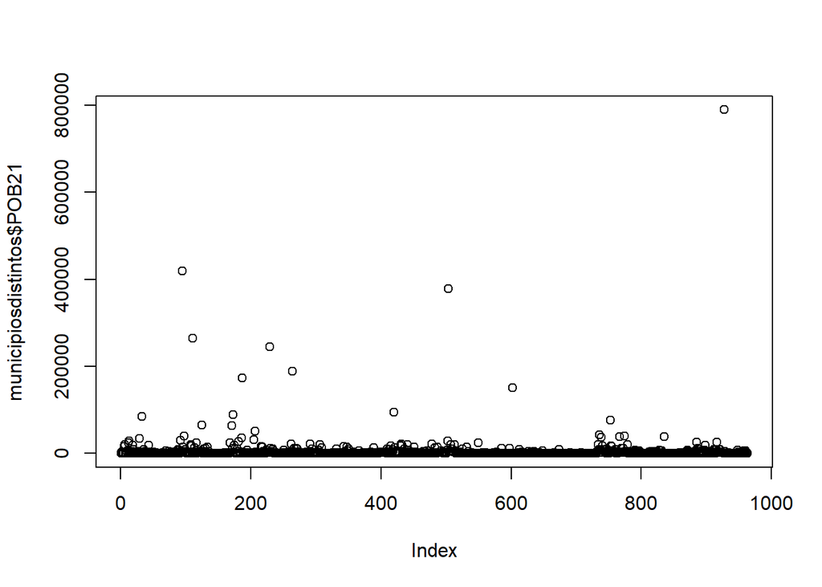

```r
options(scipen=999)
plot (municipiosdistintos$POB21)
```

### PASO 6

POR SIMPLICIDAD, VAMOS DIRECTAMENTE A ELIMINAR ESTOS MUNICIPIOS.

EN UN ANALISIS REAL, NO HECHO CON EFECTOS SIMPLEMENTE DIDACTICOS, HABRIA QUE REALIZAR UN PROCESO SIMILAR AL DE LAS PROVINCIAS.

LO PRIMERO QUE HAREMOS SERA INCLUIR EN EL NOMBRE DE TODAS LAS COLUMNAS DE CADA TABLA EL AÑO, ASI NO TENDRA LA MISMA NOMEMCLATURA EN CADA TABLA.

```r
#SI SE QUISIERA HACER USANDO "COLNAMES" POR ALGUN MOTIVO
#HAY QUE TRANSFORMARLO ANTES EN DATA FRAME.




Poblacion01 <- rename(Poblacion01,
                      HOMBRES01 = HOMBRES,
                      MUJERES01 = MUJERES,
                      CPRO01= CPRO,
                      CMUN01=CMUN)

Poblacion21 <- rename(Poblacion21,
                      HOMBRES21 = HOMBRES,
                      MUJERES21 = MUJERES,
                      CPRO21= CPRO,
                      CMUN21=CMUN)
```

```r
tabla_combinada <- inner_join(Poblacion01, Poblacion21, by = c("NOMBRE", "PROVINCIA"))
```

HACEMOS ALGUNAS COMPROBACIONES.

```r
View (tabla_combinada)
str (tabla_combinada)
```

```
## tibble [7,168 × 12] (S3: tbl_df/tbl/data.frame)
##  $ CPRO01   : chr [1:7168] "01" "01" "01" "01" ...
##  $ PROVINCIA: chr [1:7168] "Álava" "Álava" "Álava" "Álava" ...
##  $ CMUN01   : chr [1:7168] "001" "002" "049" "003" ...
##  $ NOMBRE   : chr [1:7168] "Alegría-Dulantzi" "Amurrio" "Añana" "Aramaio" ...
##  $ POB01    : num [1:7168] 1486 9695 190 1447 158 ...
##  $ HOMBRES01: num [1:7168] 763 4826 102 760 82 ...
##  $ MUJERES01: num [1:7168] 723 4869 88 687 76 ...
##  $ CPRO21   : chr [1:7168] "01" "01" "01" "01" ...
##  $ CMUN21   : chr [1:7168] "001" "002" "049" "003" ...
##  $ POB21    : num [1:7168] 2925 10307 155 1456 231 ...
##  $ HOMBRES21: num [1:7168] 1517 5084 94 756 117 ...
##  $ MUJERES21: num [1:7168] 1408 5223 61 700 114 ...
```

```r
sum(7168+963)
```

```
## [1] 8131
```

```r
# 7168 ES EL NUMERO DE FILAS DE ESTA TABLA. 963 EL NUMERO DE DIFERENCIAS (vease paso 5).

# EL RESULTADO COMO ERA DE ESPERAR, COINCIDE CON EL NUMERO DE DATOS DE LA TABLA Poblacion21
```

# CONSIDERACIONES FINALES

AQUI TERMINA LA PARTE DE LIMPIEZA DE DATOS. NO SE PUEDEN HACER MAS TRANSFORMACIONES SIN SABER EL OBJETIVO.

TODO ESTE TRABAJO ESTA PLANTEADO COMO UNA EXPOSICION DE HABILIDADES Y A EFECTOS DIDACTICOS. POR ELLO SE HAN SIMPLIFICADO ALGUNAS CUESTIONES.

EN PARTICULAR LA OPCION DE ELIMINAR LOS DATOS NO COINCIDENTES ES SIMPLE, PERO EN EL MUNDO REAL DEBERIA CONSIDERARSE CUIDADOSAMENTE SU IMPACTO SOBRE LOS RESULTADOS. PROBABLEMENTE NO FUESE LA MAS ADECUADA.